# Sampling Distributions

### Sampling Distributions Introduction

In order to gain a bit more comfort with this idea of sampling distributions, let's do some practice in python.

Below is an array that represents the students we saw in the previous videos, where 1 represents the students that drink coffee, and 0 represents the students that do not drink coffee.

```python
import numpy as np
import matplotlib.pyplot as plt
% matplotlib inline
np.random.seed(42)

students = np.array([1,0,1,1,1,1,0,0,0,0,1,1,1,1,1,1,1,1,1,1,0])
```

`1.` Find the proportion of students who drink coffee in the above array. Store this value in a variable **p**.

```python
students.mean()
```

```
0.7142857142857143
```

```python
p = students.mean()
p
```

```
0.7142857142857143
```

`2.` Use numpy's **random.choice** to simulate 5 draws from the `students` array. What is proportion of your sample drink coffee?

```python
sample1 = np.random.choice(students, 5, replace=True)
```

```python
sample1.mean()
```

```
0.59999999999999998
```

`3.` Repeat the above to obtain 10,000 additional proportions, where each sample was of size 5. Store these in a variable called `sample_props`.

```python
sample_props = []
for _ in range(10000):
    sample = np.random.choice(students, 5, replace=True)
    sample_props.append(sample.mean())
```

`4.` What is the mean proportion of all 10,000 of these proportions? This is often called **the mean of the sampling distribution**.

```python
sample_props = np.array(sample_props)
sample_props.mean()
```

```
0.71399999999999997
```

`5.` What are the variance and standard deviation for the original 21 data values?

```python
print('The standard deviation for the original data is {}'.format(students.std()))
print('The variance for the original data is {}'.format(students.var()))
```

```
The standard deviation for the original data is 0.45175395145262565
The variance for the original data is 0.20408163265306126
```

`6.` What are the variance and standard deviation for the 10,000 proportions you created?

```python
print('The standard deviation of the sampling distribution of the mean of 5 draws is {}'.format(sample_props.std()))
print('The variance for the sampling distribution of the mean of 5 draws is {}'.format(sample_props.var()))
```

```
The standard deviation of the sampling distribution of the mean of 5 draws is 0.2043624231604235
The variance for the sampling distribution of the mean of 5 draws is 0.041763999999999996
```

`7.` Compute p(1-p), which of your answers does this most closely match?

```python
p * (1 - p)
```

```
0.20408163265306123
```

`8.` Compute p(1-p)/n, which of your answers does this most closely match?

```python
p * (1 - p) / 5
```

```
0.040816326530612249
```

`9.` Notice that your answer to `8.` is commonly called the **variance of the sampling distribution**. If you were to change your first sample to be 20, what would this do for the variance of the sampling distribution? Simulate and calculate the new answers in `6.` and `8.` to check that the consistency you found before still holds.

```python
##Simulate your 20 draws
sample_props_20 = []
for _ in range(10000):
    sample = np.random.choice(students, 20, replace=True)
    sample_props_20.append(sample.mean())
```

```python
##Compare your variance values as computed in 6 and 8,
##but with your sample of 20 values
print(p*(1-p)/20) # The theoretical variance
print(np.array(sample_props_20).var()) # The simulated variance
```

```
0.0102040816327
0.010300994375
```

`10.` Finally, plot a histgram of the 10,000 draws from both the proportions with a sample size of 5 and the proportions with a sample size of 20. Each of these distributions is a sampling distribution. One is for the proportions of sample size 5 and the other a sampling distribution for proportions with sample size 20.

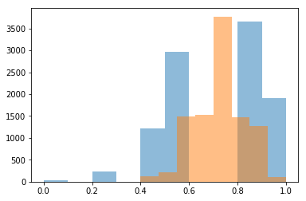

```python
plt.hist(sample_props, alpha=.5);
plt.hist(np.array(sample_props_20), alpha=.5);
```

```python
# Notice the 20 is much more normally distributed than the 5
```